# #TidyTuesday 3.9.2019: 00_intro

novica

3/9/2019

## Што е?

- Глобален настан организиран од заедницата R4DS (@R4DScommunity);
- Секој понеделник се објавува нов сет на податоци, во вторник се настаните за заедницата;
- Цел: учење на вештини за уредување на податоци и правење графици.

## Што ни треба?

- R + RStudio (https://www.rstudio.com/products/rstudio/download/);
  - Windows people: -Base R https://ftp.uni-sofia.bg/CRAN/bin/windows/base/R-3.6.1-win.exe
    - R studio: https://download1.rstudio.org/desktop/windows/RStudio-1.2.1335.exe
  - GNU/Linux people: вообичаено како за други апликации (pacman, apt, rpm)
- Tidyverse;
  - install.packages(“tidiverse”)
  - library(tidyverse)
- Github (но не задолжително).

## Околината на RStudio

- .Rmd (R Markdown) е околината во која ќе работиме;
- Корисни кратенки:
  - code chunks (ctrl+alt+i)
  - pipes (ctrl+shift+m)

## Како до помош

- help(function_name)
- ?function_name
- library(help=“package_name”)
- vignette(package=“package_name”, topic = “topipc_name”)
- пример: vignette(package=“ggplot2”, topic = “ggplot2-specs”)

## TidyTuesday!

- Податоците се тука: https://github.com/rfordatascience/tidytuesday/tree/master/data/2019/2019-09-03
- Нов R Notebook: Мени: File -> New File -> R notebook
- Ставете го кодот во chunks! (ctrl+alt+i)

## The code 1

Load the libraries

```r
suppressPackageStartupMessages(library(tidyverse))
suppressPackageStartupMessages(library(scales))
```

## The code 2

Load the data from github

```r
cpu <-
  readr::read_csv(
    "https://raw.githubusercontent.com/rfordatascience/tidytuesday/master/data/2019/2019-09-03/cpu.csv"
  )
gpu <-
  readr::read_csv(
    "https://raw.githubusercontent.com/rfordatascience/tidytuesday/master/data/2019/2019-09-03/gpu.csv"
  )
ram <-
  readr::read_csv(
    "https://raw.githubusercontent.com/rfordatascience/tidytuesday/master/data/2019/2019-09-03/ram.csv"
  )
```

## The code 3

Make a plot

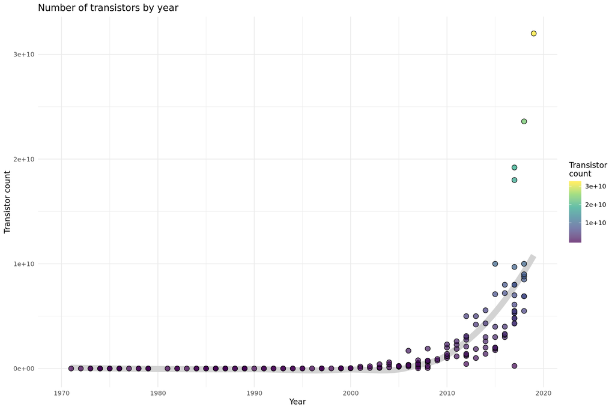

```r
ggplot(cpu, aes(x=date_of_introduction, y=transistor_count)) +
  geom_smooth(color="lightgrey", size=4, se=FALSE) +
  geom_point(aes(fill=transistor_count), size=3, pch=21) +
  scale_fill_viridis_c(name="Transistor\ncount", alpha=.7) +
  labs(x="Year", y="Transistor count") +
  labs(title="Number of transistors by year") +
  theme_minimal()
```

## The code 4

Make another plot

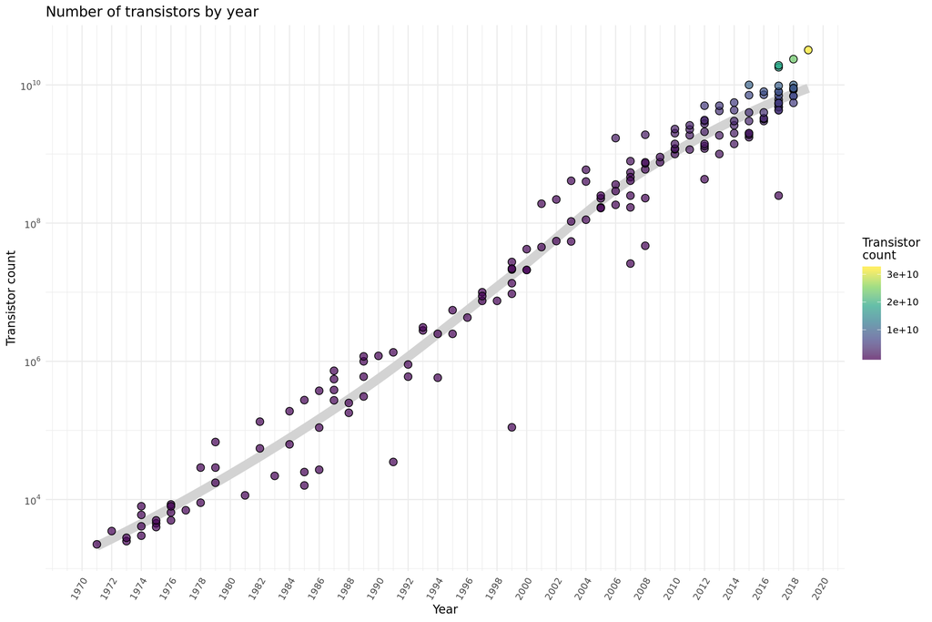

```r
ggplot(cpu, aes(x=date_of_introduction, y=transistor_count)) +
  geom_smooth(color="lightgrey", size=4, se=FALSE) +
  geom_point(aes(fill=transistor_count), size=3, pch=21) +
  scale_fill_viridis_c(name="Transistor\ncount", alpha=.7) +
  scale_y_continuous(trans="log10",
          breaks = trans_breaks("log10", function(x) 10^x),
          labels = trans_format("log10", math_format(10^.x))) +
  scale_x_continuous(breaks=seq(1970, 2020, 2)) +
  labs(x="Year", y="Transistor count") +
  labs(title="Number of transistors by year") +
  theme_minimal() +
  theme(axis.text.x = element_text(angle=60, hjust=1, vjust=1))
```

## R референци

- R4DS slack канал наменет за почетници што вежбаа со #TidyTuesday
- R for Data science (https://r4ds.had.co.nz/)
- Advanced R (http://adv-r.had.co.nz/)
- TidyTuesday podcast (https://podtail.com/podcast/tidy-tuesday/)

## Други ресурси што ги искористивме

- Хумор за почеток (https://www.linkedin.com/posts/florian-gr%C3%BCning-03019653_datascience-machinelearning-deeplearning-ugcPost-6571720278366273536-UJmS)
- The Evolution of a ggplot (Ep. 1) (https://cedricscherer.netlify.com/2019/05/17/the-evolution-of-a-ggplot-ep.-1/)
- R you ready to make charts? (https://www.williamrchase.com/slides/ggplot_intro.html)
- Simpsons’ Guest Appearances are Growing (https://evamaerey.github.io/tidytuesday_walk_through/simpsons.html)
- Technological Progress (https://ourworldindata.org/technological-progress)